# L1: Introduction to Financial Data – A Case Study of Technical Analysis

```r
# set up your working directory at the beginning of your script.
# load the libraries you will use
setwd("C:/Users/siche/Documents/teaching/Introduction to Financial Data Analysis/L1")
library(zoo)
library(dplyr)
```

# Trend: SMA

## Step 1: Obtain Closing Prices for AAPL

Since we have already imported the AAPL stock price data into data aapl, we only need to extract the closing price from that data object.

```r
# load aapl price
aapl = read.csv("aapl.csv")
aapl.sma = aapl[,c("permno","date","prc")]
str(aapl.sma)
```

```
## 'data.frame':    1006 obs. of  3 variables:
##  $ permno: int  14593 14593 14593 14593 14593 14593 14593 14593 14593 14593 ...
##  $ date  : Factor w/ 1006 levels "2015-01-02","2015-01-05",..: 1 2 3 4 5 6 7 8 9 10 ...
##  $ prc   : num  109 106 106 108 112 ...
```

```r
aapl.sma$date = as.Date(aapl.sma$date)
print(aapl.sma[1:3,])
```

```
##   permno       date    prc
## 1  14593 2015-01-02 109.33
## 2  14593 2015-01-05 106.25
## 3  14593 2015-01-06 106.26
```

```r
# check missing data
any(is.na(aapl.sma$prc))
```

```
## [1] FALSE
```

```r
# example: rollmean function
tmp = c(NA,1,2,NA,4,5,6,7,NA)
tmp
```

```
## [1] NA  1  2 NA  4  5  6  7 NA
```

```r
rollmean(tmp,k=2)
```

```
## [1]  NA 1.5  NA  NA 4.5 5.5 6.5  NA
```

```r
rollmean(tmp,k=2,fill=NA)
```

```
## [1]  NA 1.5  NA  NA 4.5 5.5 6.5  NA  NA
```

```r
rollmean(tmp,k=2,fill=NA,align='right')
```

```
## [1]  NA  NA 1.5  NA  NA 4.5 5.5 6.5  NA
```

```r
# Calculate the 50 day and 200 day moving average of price use base R

aapl.sma$sma50 = rollmean(aapl.sma$prc,k=50,fill=NA,align='right')
aapl.sma$sma200 = rollmean(aapl.sma$prc,k=200,fill=NA,align='right')

# Alternatively, dplyr syntax to create 50 day and 200 day moving average of price (same results as using the base R syntax)
aapl.sma = aapl.sma %>%
  mutate(sma50=rollmean(prc,k=50,fill=NA,align='right'),
         sma200=rollmean(prc,k=200,fill=NA,align='right'))
aapl.sma[48:52,]
```

```
##    permno       date    prc    sma50 sma200
## 48  14593 2015-03-12 124.45       NA     NA
## 49  14593 2015-03-13 123.59       NA     NA
## 50  14593 2015-03-16 124.95 119.6581     NA
## 51  14593 2015-03-17 127.04 120.0123     NA
## 52  14593 2015-03-18 128.47 120.4567     NA
```

## Step 3: Subset to show data after 2016.

```r
aapl.sma = aapl.sma[aapl.sma$date>='2016-01-01',]
# use dplyr instead

aapl.sma = aapl.sma %>% filter(date>='2016-01-01')
```

## Step 4: Plot the SMA

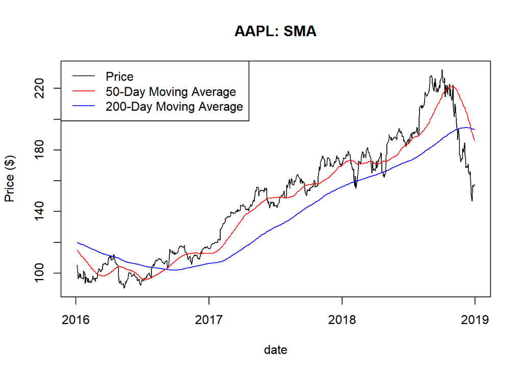

```r
# before your plot, it's good habbit to make sure data are ordered by dates
aapl.sma = aapl.sma[order(aapl.sma$date),]

# use dplyr to order data instead
aapl.sma = aapl.sma %>% arrange(date)

# plot
# range function gives the max and min value of a matrix/data.frame/vector etc.
yrange=range(aapl.sma[,c("prc","sma50","sma200")])

plot(aapl.sma$prc~aapl.sma$date,
     type='l',
     xlab='date',
     ylab='Price ($)',
     ylim=yrange,
     main="AAPL: SMA")
lines(aapl.sma$sma50~aapl.sma$date,col='red')
lines(aapl.sma$sma200~aapl.sma$date,col='blue')
legend("topleft",
       c("Price","50-Day Moving Average","200-Day Moving Average"),
       lty=c(1,1,1),
       col=c("black","red","blue"))
```

- If the 50-day moving average cross above the 200-day moving average, which is called a bullish crossover, this may be taken as an indicator to buy the stock.
- Conversely, if the 50-day moving average crosses below the 200-day moving average, which is known as a bearish crossover, this may be taken as an indication to sell the stock.

## Wrap up SMA into a user-defined function

- The input of the function is price of a stock
- Other arguments is two numbers of days to calculate the moving averages

```r
# define a function
FunctionName = function(x,argument1,argument1,...){
  rst = some operations on x using argument1, argument2,etc..
  return(rst)
}

# call your function
my.val = Function(x=price,argument1=10,argument2=30)
```

- SMA function which takes the price vector as input
- argument1 = the short MA window
- argument2 = the long MA window
- return a dataframe with original price, MA of the short window and MA of the long window

```r
MySMA = function(x,window1,window2){
 sma.1 = rollmean(x,k=window1,fill=NA,align='right')
 sma.2 = rollmean(x,k=window2,fill=NA,align='right')
 rst = data.frame(price=x, sma.1 = sma.1 , sma.2 = sma.2)
 return(rst)
}
# call your function
smatest = MySMA(aapl$prc,window1=2,window2=5)
head(smatest,10)
```

```
##     price   sma.1   sma.2
## 1  109.33      NA      NA
## 2  106.25 107.790      NA
## 3  106.26 106.255      NA
## 4  107.75 107.005      NA
## 5  111.89 109.820 108.296
## 6  112.01 111.950 108.832
## 7  109.25 110.630 109.432
## 8  110.22 109.735 110.224
## 9  109.80 110.010 110.634
## 10 106.82 108.310 109.620
```

# Volatility: Bollinger Bands

## Step 1: Obtain Closing Prices of AAPL

```r
aapl = read.csv("aapl.csv")
aapl.bb = aapl[,c("permno","date","prc")]
aapl.bb$date = as.Date(aapl.bb$date)
head(aapl.bb)
```

```
##   permno       date    prc
## 1  14593 2015-01-02 109.33
## 2  14593 2015-01-05 106.25
## 3  14593 2015-01-06 106.26
## 4  14593 2015-01-07 107.75
## 5  14593 2015-01-08 111.89
## 6  14593 2015-01-09 112.01
```

## Step 2: Calculate Rolling 20-Day Mean and Standard Deviation

- We use the rollmean command with k=20 to calculate the 20-day moving average.
- For the standard deviation, we use the rollapply command, which allows us to apply a function on a rolling basis.
- The FUN=sd tells R that the function we want to apply is the standard deviation and the width=20 tells R that it is a 20-day standard deviation that we want to calculate.

```r
aapl.bb = aapl.bb %>%
  arrange(date) %>%
  mutate(avg = rollmean(prc,k=20,fill=NA,align='right'),
         sd = rollapply(prc,width=20,FUN=sd,na.rm=T,fill=NA,align='right'))
tail(aapl.bb)
```

```
##      permno       date    prc      avg        sd
## 1001  14593 2018-12-21 150.73 170.3580  8.333745
## 1002  14593 2018-12-24 146.83 169.0850  9.832809
## 1003  14593 2018-12-26 157.17 168.2125 10.086741
## 1004  14593 2018-12-27 156.15 167.3080 10.326041
## 1005  14593 2018-12-28 156.23 166.0725 10.084582
## 1006  14593 2018-12-31 157.74 164.9820  9.723224
```

## Step 3: Subset to 2016

```r
aapl.bb = aapl.bb %>% filter(substr(date,1,4)=='2016')
```

## Step 4: Calculate the Bollinger Bands

```r
aapl.bb = aapl.bb %>%
  mutate(sd2up=avg+2*sd,
         sd2down=avg-2*sd)
head(aapl.bb,3)
```

```
##   permno       date    prc     avg       sd    sd2up  sd2down
## 1  14593 2016-01-04 105.35 110.726 4.563188 119.8524 101.5996
## 2  14593 2016-01-05 102.71 109.910 4.458073 118.8261 100.9939
## 3  14593 2016-01-06 100.70 109.031 4.454024 117.9390 100.1230
```

## Step 5: Plot the Bollinger Bands

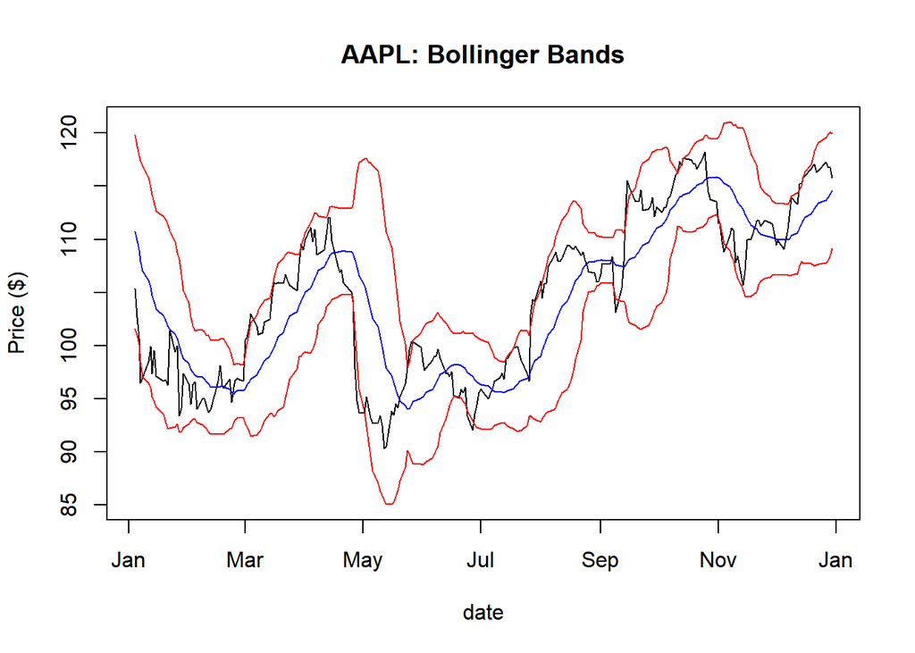

```r
yrange = range(aapl.bb[,c("prc","avg","sd2up","sd2down")])
plot(aapl.bb$prc~aapl.bb$date,
     ylim=yrange,
     xlab='date',
     ylab='Price ($)',
     type='l',
     main='AAPL: Bollinger Bands')
lines(aapl.bb$avg~aapl.bb$date,
      col='blue')
lines(aapl.bb$sd2up~aapl.bb$date,
      col='red')
lines(aapl.bb$sd2down~aapl.bb$date,
      col='red')
```

- Assuming a normal distribution, two standard deviations in either direction from the mean should cover pretty much the majority of the data.
- Most of the closing prices fell within the Bollinger Bands. For a trend follower, when the stock price was right around the upper band, this may be taken as an indication that the stock is overbought.
- Conversely, when the stock price moved right around the lower band, this may be taken as an indication that the stock is oversold.

# Momentum: RSI

## Step 1: Obtain Closing Prices and Price Difference

```r
aapl.rsi=read.csv("aapl.csv")
aapl.rsi = aapl.rsi %>%
  select(permno,date,prc) %>%
  arrange(date) %>%
  mutate(date=as.Date(date),
         delta=prc-lag(prc,1))
head(aapl.rsi,3)
```

```
##   permno       date    prc       delta
## 1  14593 2015-01-02 109.33          NA
## 2  14593 2015-01-05 106.25 -3.08000183
## 3  14593 2015-01-06 106.26  0.01000214
```

## Step 2: Create Dummy Variables to Indicate Whether Price Went Up or Price Went Down

- If price goes up/down, up=1/0
- If price goes down/up, down=1/0

```r
aapl.rsi = aapl.rsi %>%
  mutate(up=ifelse(delta>0,1,0),
         down=ifelse(delta<0,1,0))
head(aapl.rsi)
```

```
##   permno       date    prc       delta up down
## 1  14593 2015-01-02 109.33          NA NA   NA
## 2  14593 2015-01-05 106.25 -3.08000183  0    1
## 3  14593 2015-01-06 106.26  0.01000214  1    0
## 4  14593 2015-01-07 107.75  1.48999786  1    0
## 5  14593 2015-01-08 111.89  4.13999939  1    0
## 6  14593 2015-01-09 112.01  0.12000275  1    0
```

## Step 3: Calculate Delta for Up Days and Delta for Down Days

- The series of Delta on up days is up.val = delta * up.
- The series of Delta on down days is down.val = -delta * down.

```r
aapl.rsi = aapl.rsi %>%
  mutate(up.val=delta*up,
         down.val=-delta*down)
head(aapl.rsi)
```

```
##   permno       date    prc       delta up down     up.val down.val
## 1  14593 2015-01-02 109.33          NA NA   NA         NA       NA
## 2  14593 2015-01-05 106.25 -3.08000183  0    1 0.00000000 3.080002
## 3  14593 2015-01-06 106.26  0.01000214  1    0 0.01000214 0.000000
## 4  14593 2015-01-07 107.75  1.48999786  1    0 1.48999786 0.000000
## 5  14593 2015-01-08 111.89  4.13999939  1    0 4.13999939 0.000000
## 6  14593 2015-01-09 112.01  0.12000275  1    0 0.12000275 0.000000
```

## Step 4: Calculate Initial Up and Down 14-Day Averages

```r
aapl.rsi = aapl.rsi[2:nrow(aapl.rsi),] %>%
  mutate(up.first.avg=rollapply(up.val,
                                width=14,
                                align='right',
                                fill=NA,FUN=mean,na.rm=T),
         down.first.avg=rollapply(down.val,
                                  width=14,
                                  align='right',
                                  fill=NA,FUN=mean,na.rm=T))
head(aapl.rsi,20)
```

```
##    permno       date    prc       delta up down     up.val  down.val
## 1   14593 2015-01-05 106.25 -3.08000183  0    1 0.00000000 3.0800018
## 2   14593 2015-01-06 106.26  0.01000214  1    0 0.01000214 0.0000000
## 3   14593 2015-01-07 107.75  1.48999786  1    0 1.48999786 0.0000000
## 4   14593 2015-01-08 111.89  4.13999939  1    0 4.13999939 0.0000000
## 5   14593 2015-01-09 112.01  0.12000275  1    0 0.12000275 0.0000000
## 6   14593 2015-01-12 109.25 -2.76000214  0    1 0.00000000 2.7600021
## 7   14593 2015-01-13 110.22  0.97000122  1    0 0.97000122 0.0000000
## 8   14593 2015-01-14 109.80 -0.41999817  0    1 0.00000000 0.4199982
## 9   14593 2015-01-15 106.82 -2.98000336  0    1 0.00000000 2.9800034
## 10  14593 2015-01-16 105.99 -0.83000183  0    1 0.00000000 0.8300018
## 11  14593 2015-01-20 108.72  2.73000336  1    0 2.73000336 0.0000000
## 12  14593 2015-01-21 109.55  0.83000183  1    0 0.83000183 0.0000000
## 13  14593 2015-01-22 112.40  2.84999847  1    0 2.84999847 0.0000000
## 14  14593 2015-01-23 112.98  0.58000183  1    0 0.58000183 0.0000000
```

[output cut: 27 more lines]

## Step 5: Calculate the Wilder Exponential Moving Average to Calculate Final Up and Down 14-Day Averages

```r
# initialise the up.avg and down.avg with up.first.avg and down.first.avg values
aapl.rsi$up.avg = aapl.rsi$up.first.avg
aapl.rsi$down.avg = aapl.rsi$down.first.avg

# fill up.avg and down.avg values with updated value for t>=15
for (t in 15:length(aapl.rsi$up.avg)){
  aapl.rsi$up.avg[t] = aapl.rsi$up.avg[t-1]*13/14 + aapl.rsi$up.val[t]*1/14
  aapl.rsi$down.avg[t] = aapl.rsi$down.avg[t-1]*13/14 + aapl.rsi$down.val[t]*1/14
}

head(aapl.rsi,20)
```

```
##    permno       date    prc       delta up down     up.val  down.val
## 1   14593 2015-01-05 106.25 -3.08000183  0    1 0.00000000 3.0800018
## 2   14593 2015-01-06 106.26  0.01000214  1    0 0.01000214 0.0000000
## 3   14593 2015-01-07 107.75  1.48999786  1    0 1.48999786 0.0000000
## 4   14593 2015-01-08 111.89  4.13999939  1    0 4.13999939 0.0000000
## 5   14593 2015-01-09 112.01  0.12000275  1    0 0.12000275 0.0000000
## 6   14593 2015-01-12 109.25 -2.76000214  0    1 0.00000000 2.7600021
## 7   14593 2015-01-13 110.22  0.97000122  1    0 0.97000122 0.0000000
## 8   14593 2015-01-14 109.80 -0.41999817  0    1 0.00000000 0.4199982
## 9   14593 2015-01-15 106.82 -2.98000336  0    1 0.00000000 2.9800034
## 10  14593 2015-01-16 105.99 -0.83000183  0    1 0.00000000 0.8300018
## 11  14593 2015-01-20 108.72  2.73000336  1    0 2.73000336 0.0000000
## 12  14593 2015-01-21 109.55  0.83000183  1    0 0.83000183 0.0000000
## 13  14593 2015-01-22 112.40  2.84999847  1    0 2.84999847 0.0000000
## 14  14593 2015-01-23 112.98  0.58000183  1    0 0.58000183 0.0000000
```

[output cut: 27 more lines]

## Step 6: Calculate the RSI

```r
# RS = upside wema/downside wema
# RSI = 100-100/(1+RS)
aapl.rsi$rs=aapl.rsi$up.avg/aapl.rsi$down.avg
aapl.rsi$rsi=100-100/(1+aapl.rsi$rs)
head(aapl.rsi,20)
```

```
##    permno       date    prc       delta up down     up.val  down.val
## 1   14593 2015-01-05 106.25 -3.08000183  0    1 0.00000000 3.0800018
## 2   14593 2015-01-06 106.26  0.01000214  1    0 0.01000214 0.0000000
## 3   14593 2015-01-07 107.75  1.48999786  1    0 1.48999786 0.0000000
## 4   14593 2015-01-08 111.89  4.13999939  1    0 4.13999939 0.0000000
## 5   14593 2015-01-09 112.01  0.12000275  1    0 0.12000275 0.0000000
## 6   14593 2015-01-12 109.25 -2.76000214  0    1 0.00000000 2.7600021
## 7   14593 2015-01-13 110.22  0.97000122  1    0 0.97000122 0.0000000
## 8   14593 2015-01-14 109.80 -0.41999817  0    1 0.00000000 0.4199982
## 9   14593 2015-01-15 106.82 -2.98000336  0    1 0.00000000 2.9800034
## 10  14593 2015-01-16 105.99 -0.83000183  0    1 0.00000000 0.8300018
## 11  14593 2015-01-20 108.72  2.73000336  1    0 2.73000336 0.0000000
## 12  14593 2015-01-21 109.55  0.83000183  1    0 0.83000183 0.0000000
## 13  14593 2015-01-22 112.40  2.84999847  1    0 2.84999847 0.0000000
## 14  14593 2015-01-23 112.98  0.58000183  1    0 0.58000183 0.0000000
```

[output cut: 27 more lines]

## Step 7: Subset to Show 2016 Data

```r
aapl.rsi = aapl.rsi %>% filter(substr(date,1,4)=='2016')
```

## Step 8: Plot the RSI and the Price

- The range of the y-axis has to be between 0 and 100.

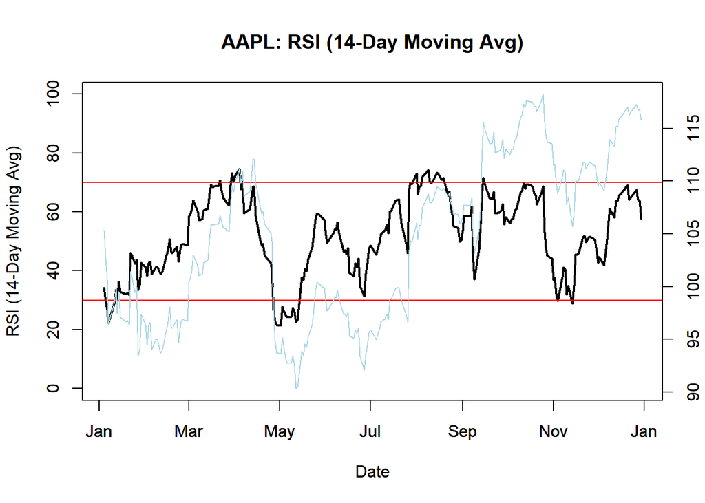

```r
plot(aapl.rsi$rsi~aapl.rsi$date,
     ylab='RSI (14-Day Moving Avg)',
     xlab='Date',
     ylim=c(0,100),
     lwd=2,
     type='l',
     main='AAPL: RSI (14-Day Moving Avg)')
abline(h=c(30,70),col='red')
par(new=T)
plot(aapl.rsi$prc~aapl.rsi$date,
     xlab='',
     ylab='',
     yaxt='n',
     type='l',col='lightblue')
axis(4)
```